# Distribution of Public Service of Canada Employees by Designated Group and Region of Work

## checking if our r is working

```
print("Hello R world")
```

## Analysis of Table 2

### we are loading required libraries

Loading required libraries

```r
install.packages(c("readxl", "dplyr", "ggplot2", "tidyr"))
library(readxl)
library(janitor)
library(dplyr)
library(ggplot2)
library(tidyr)
```

### loading the data and cleaning the names

we also cleaned the data to use numbers only, excluding the percentages

```r
library(readxl)
tab02_eng <- read_excel("~/Documents/programming/R/velma/keira/tab02-eng.xls", skip = 4, n_max = 18)
head(tab02_eng)
```

| Region of Work | All Employees | Women | ...4 | Aboriginal Peoples | ...6 | Persons with Disabilities | ...8 | Members of a Visible Minority Group | ...10 |
| --- | --- | --- | --- | --- | --- | --- | --- | --- | --- |
| NA | Number | Number | % | Number | % | Number | % | Number | % |
| Newfoundland and Labrador | 2784 | 1177 | 42.277298850574702 | 173 | 6.2140804597701198 | 153 | 5.4956896551724101 | 52 | 1.8678160919540201 |
| Prince Edward Island | 1554 | 980 | 63.063063063063098 | 44 | 2.8314028314028299 | 112 | 7.20720720720721 | 39 | 2.50965250965251 |
| Nova Scotia | 8349 | 3567 | 42.723679482572798 | 412 | 4.9347227212839897 | 593 | 7.1026470235956403 | 490 | 5.8689663432746402 |
| New Brunswick | 6387 | 3572 | 55.926099890402398 | 233 | 3.6480350712384499 | 334 | 5.2293721622044798 | 154 | 2.4111476436511698 |
| Quebec (without the NCR) † | 20427 | 10669 | 52.229891809859502 | 420 | 2.0561022176531099 | 672 | 3.2897635482449701 | 1999 | 9.7860674597346708 |

```r
print(dim(tab02_eng))
```

```
## [1] 18 10
```

```r
tab02_eng <- clean_names(tab02_eng)
selected_colnames <- c("region_of_work", "all_employees", "women", "members_of_a_visible_minority_group","persons_with_disabilities" , "aboriginal_peoples")
head(tab02_eng)
```

| region_of_work | all_employees | women | x4 | aboriginal_peoples | x6 | persons_with_disabilities | x8 | members_of_a_visible_minority_group | x10 |
| --- | --- | --- | --- | --- | --- | --- | --- | --- | --- |
| NA | Number | Number | % | Number | % | Number | % | Number | % |
| Newfoundland and Labrador | 2784 | 1177 | 42.277298850574702 | 173 | 6.2140804597701198 | 153 | 5.4956896551724101 | 52 | 1.8678160919540201 |
| Prince Edward Island | 1554 | 980 | 63.063063063063098 | 44 | 2.8314028314028299 | 112 | 7.20720720720721 | 39 | 2.50965250965251 |
| Nova Scotia | 8349 | 3567 | 42.723679482572798 | 412 | 4.9347227212839897 | 593 | 7.1026470235956403 | 490 | 5.8689663432746402 |
| New Brunswick | 6387 | 3572 | 55.926099890402398 | 233 | 3.6480350712384499 | 334 | 5.2293721622044798 | 154 | 2.4111476436511698 |
| Quebec (without the NCR) † | 20427 | 10669 | 52.229891809859502 | 420 | 2.0561022176531099 | 672 | 3.2897635482449701 | 1999 | 9.7860674597346708 |

```r
subset_data <- tab02_eng[, selected_colnames]
#subset_data <- filter(subset_data, !is.na(region_of_work))
subset_data <- subset_data[complete.cases(tab02_eng$region_of_work), ]
head(subset_data)
```

| region_of_work | all_employees | women | members_of_a_visible_minority_group | persons_with_disabilities | aboriginal_peoples |
| --- | --- | --- | --- | --- | --- |
| Newfoundland and Labrador | 2784 | 1177 | 52 | 153 | 173 |
| Prince Edward Island | 1554 | 980 | 39 | 112 | 44 |
| Nova Scotia | 8349 | 3567 | 490 | 593 | 412 |
| New Brunswick | 6387 | 3572 | 154 | 334 | 233 |
| Quebec (without the NCR) † | 20427 | 10669 | 1999 | 672 | 420 |
| NCR (Quebec) † | 24333 | 13927 | 3162 | 1310 | 1276 |

### visualization of the data

1. Drawing a bar graph showing the different distrbutions of employees categories across regions
1. Converted the data to numerical data
2. Created a bar graph

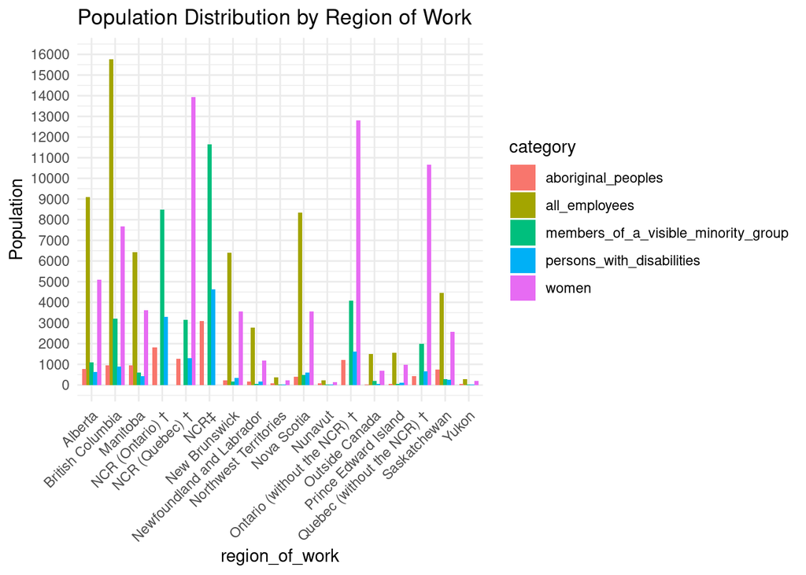

```r
subset_data <- subset_data %>%
  mutate_at(vars(all_employees, women, members_of_a_visible_minority_group, persons_with_disabilities, aboriginal_peoples),
            as.numeric)

subset_data_long <- subset_data %>%
  gather(key = "category", value = "value", -region_of_work)

ggplot(subset_data_long, aes(x = region_of_work, y = value, fill = category)) +
  geom_bar(stat = "identity", position = position_dodge(width = 0.8)) +
  labs(title = "Population Distribution by Region of Work",
       y = "Population") +
  theme_minimal() +
  theme(axis.text.x = element_text(angle = 45, hjust = 1)) +
  scale_y_continuous(limits = c(0, 16000), breaks = seq(0, 16000, by = 1000))
```

from the bar graph above you can see:

- that women are the second most employed across the different regions
1. distribution of employment across regions

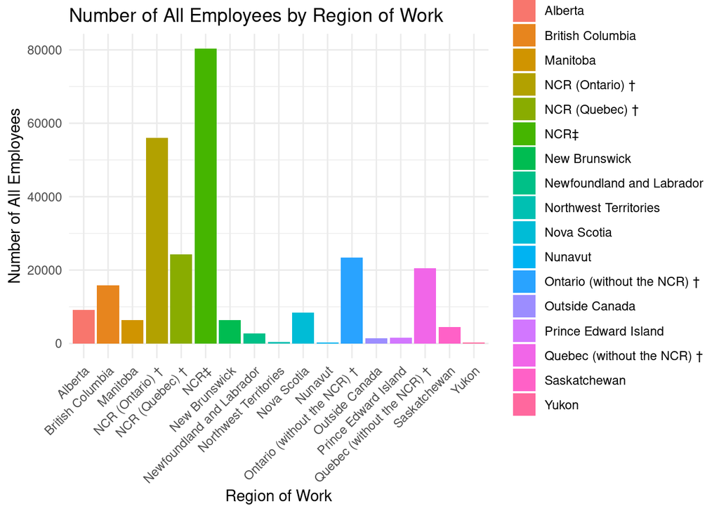

```r
ggplot(subset_data, aes(x = region_of_work, y = all_employees, fill = region_of_work)) +
  geom_bar(stat = "identity") +
  labs(title = "Number of All Employees by Region of Work",
       x = "Region of Work",
       y = "Number of All Employees") +
  theme_minimal() +
  theme(axis.text.x = element_text(angle = 45, hjust = 1))
```

from the bar graph above you can deduce:

- there is a high rate of employment in NCR+ compared to other regions of work
2. Scatter plot for distribution of women across regions of work

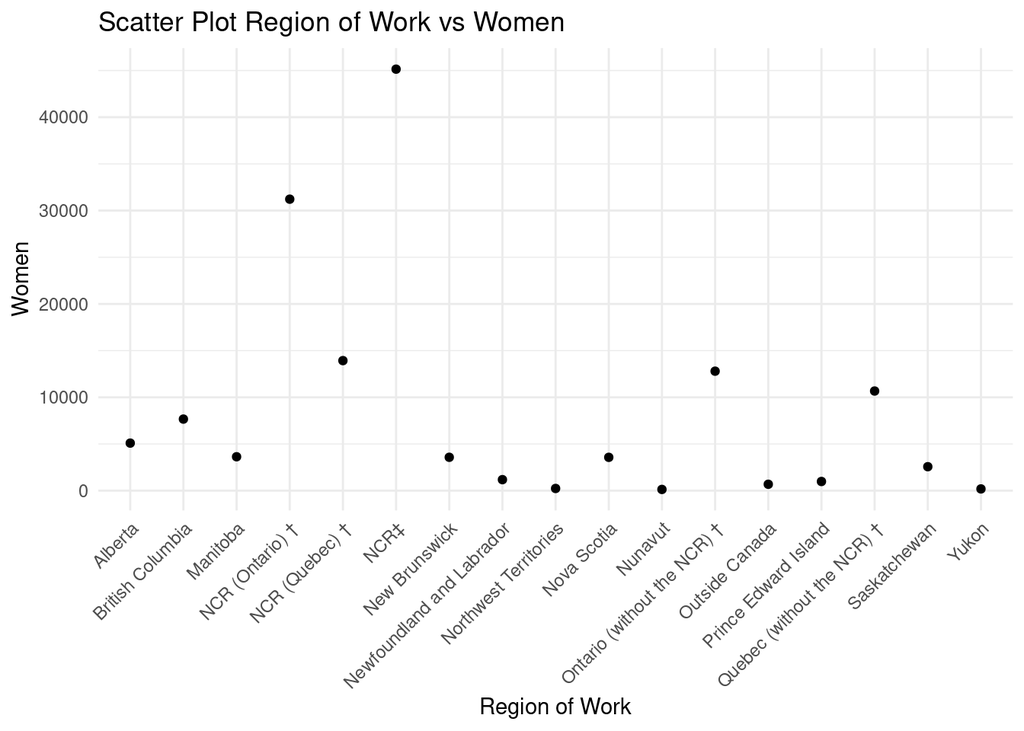

```r
ggplot(subset_data, aes(x = region_of_work, y = women)) +
  geom_point() +
  labs(title = "Scatter Plot Region of Work vs Women",
       x = "Region of Work",
       y = "Women") +
  theme_minimal() + theme(axis.text.x = element_text(angle = 45, hjust = 1))
```

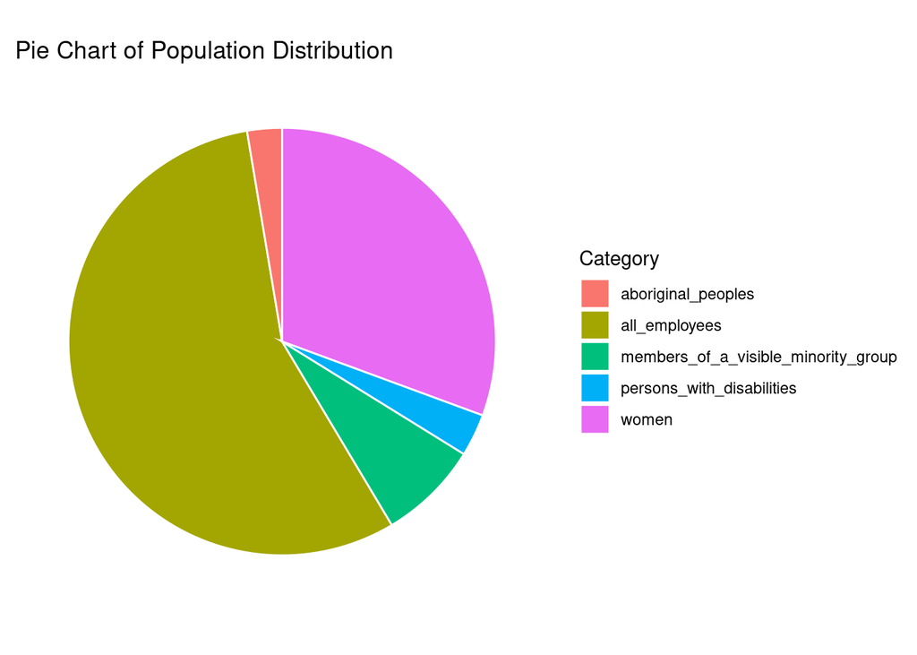

```r
summary_data <- subset_data %>%
  summarise(
    all_employees = sum(all_employees),
    women = sum(women),
    members_of_a_visible_minority_group = sum(members_of_a_visible_minority_group),
    persons_with_disabilities = sum(persons_with_disabilities),
    aboriginal_peoples = sum(aboriginal_peoples)
  )
summary_data_long <- gather(summary_data, key = "category", value = "value")
ggplot(summary_data_long, aes(x = "", y = value, fill = category)) +
  geom_bar(stat = "identity", width = 1, color = "white") +
  coord_polar("y") +
  labs(title = "Pie Chart of Population Distribution",
       fill = "Category") +
  theme_minimal() +
  theme(axis.text = element_blank(),
        axis.title = element_blank(),
        panel.grid = element_blank())
```

from the pie chart above we can deduce:

- women are the second most employed category
- Aborginal people and person with disabilities have a few representation in the job industry